# Time Zone Travel Is Associated With Reductions In Competitive Powerlifting Performance In U.S. Adults

Authors

Affiliation

Jason Dude

University of Utah

Christopher Depner

University of Utah

## Abstract

### Introduction

Sleep loss and circadian misalignment—such as that caused by time zone travel—impair neuromuscular performance and power output in laboratory settings. However, limited evidence exists on whether these effects impair real-world performance in strength competitions.

### Purpose

To determine whether the number and direction of time zones crossed before competition predicts changes in powerlifting performance versus a lifter’s prior meet.

### Methods

Public meet results were obtained from the OpenPowerlifting database. Inclusion criteria: U.S. men and women (24-64 y), raw USAPL/USPA squat-bench-deadlift (SBD) events held in the U.S., valid attempts in all three lifts, and ≥2 meets within 30-365 days with minimal body mass change (<5 kg). Time zone offsets were determined using lifter home state and meet state. To isolate the effect of travel into a new time zone, only meets where the previous meet occurred in the lifter’s home time zone were included. Performance was defined as total weight lifted (TotalKg), and performance change was calculated within-lifter as ΔTotal = current TotalKg − previous TotalKg. Implausible changes (< −25 kg or > +75 kg) were excluded. A linear mixed-effects model (random intercept for lifter) estimated the effect of time zone travel on ΔTotal, adjusting for sex, age class, body mass, number of meets, and days since prior meet.

### Results

13,130 repeat U.S. lifters (46% women) met inclusion criteria. Performance gains were greatest when competing locally (~11–12 kg) and were attenuated when crossing time zones, with the largest reduction observed after crossing 1–2 time zones, independent of travel direction (Eastward, 1 time zone: β = −4.0 kg, 95% CI: −6.0 to −2.0, p<0.01; Westward, 1 time zone: β = −4.0 kg, 95% CI: −5.5 to −2.4, p<0.01).

### Conclusion

These findings suggest time zone travel impairs performance in real-world competition conditions. Athletes and coaches should consider arriving earlier to allow sufficient adjustment to the new time zone and optimize sleep and circadian phase prior to competition.

## Code

```r
library(tidyverse)
library(lubridate)
library(lme4)
library(lmerTest)
library(lutz)
```

```r
df_raw <- read_csv("../data/openpowerlifting-2025-11-01-695242b2.csv")
```

```r
df_filt <- df_raw |>
  mutate(
    Date = ymd(Date, quiet = TRUE),
    Sex = as.factor(Sex),
    Equipment = as.factor(Equipment),
  ) |>
  filter(
    !is.na(AgeClass),
    !is.na(State),
    !is.na(Country),
    !is.na(MeetCountry),
    !is.na(MeetState),
    !is.na(Best3SquatKg),
    !is.na(Best3BenchKg),
    !is.na(Best3DeadliftKg),
    !is.na(Dots),
    !is.na(Country),
    !is.na(Tested)
  ) |>
  filter(
    Country == "USA",
    MeetCountry == "USA",
    Federation %in% c("USAPL", "USPA"),
    State != "Guam",
    MeetState != "Guam",
    Best3SquatKg > 0,
    Best3DeadliftKg > 0,
    Best3BenchKg > 0,
    Sex %in% c("M", "F"),
    Equipment == "Raw",
    AgeClass %in% c(
      "24-34",
      "35-39",
      "40-44",
      "45-49",
      "50-54",
      "55-59",
      "60-64"
    ),
    Event == "SBD",
    Place != "DQ",
    Tested == "Yes",
    Sanctioned == "Yes",
    year(Date) > 2005,
    year(Date) != 2020
  )
```

```r
state_timezone <- function(states, dates = Sys.Date()) {
  if (length(dates) == 1) {
   dates <- rep(dates, length(states))
  }
  stopifnot(length(states) == length(dates))

  # lookup table for 50 states + DC
  us_states_tbl <- tibble::tibble(
    StateName = c(state.name, "District Of Columbia"),
    StateAbb = c(state.abb, "DC"),
    lon = c(as.numeric(state.center$x), -77.0369),
    lat = c(as.numeric(state.center$y), 38.9072)
  )

  # check that abbreviations are valid
  valid_idx <- states %in% us_states_tbl$StateAbb
  if (any(!valid_idx)) {
    warning(
      "Invalid state abbreviations: ",
      paste(unique(states[!valid_idx]), collapse = ", ")
    )
  }

  # filter only valid pairs
  states <- states[valid_idx]
  dates <- dates[valid_idx]

  # compute per-state offset
  results <- map2_dfr(states, dates, function(st, dt) {
    row <- us_states_tbl[us_states_tbl$StateAbb == st, ]
    tz <- lutz::tz_lookup_coords(
      lat = row$lat,
      lon = row$lon,
      method = "fast",
      warn = FALSE
    )
    # compute offset correctly, accounting for time of year
    local_noon_UTC <- with_tz(as.POSIXct(paste0(dt, " 12:00:00"), tz = tz), "UTC")
    utc_noon <- as.POSIXct(paste0(dt, " 12:00:00"), tz = "UTC")
    offset_h <- -as.numeric(difftime(local_noon_UTC, utc_noon, units = "hours"))

    return(
      tibble(
        State = st,
        Date = dt,
        TimeZone = tz,
        UTC_Offset_h = offset_h
      )
    )
  })

  return(results)
}
```

```r
split_states <- c(
  "FL", "TN", "KY", "IN", "MI",
  "TX", "ND", "SD", "NE", "KS",
  "ID", "OR"
)

df_filt_nosplit <- df_filt |>
  filter(
    !(State %in% split_states),
    !(MeetState %in% split_states)
  )

# use UTC offsest difference to derive direction of travel
df_tz <- df_filt_nosplit |>
  mutate(
    StateTzOffset = state_timezone(State, Date)$UTC_Offset_h,
    MeetStateTzOffset = state_timezone(MeetState, Date)$UTC_Offset_h,
    StateMeetTzDiff = MeetStateTzOffset - StateTzOffset,
    Direction = case_when(
      StateMeetTzDiff == 0 ~ "Local",
      StateMeetTzDiff > 0 ~ "Eastward",
      StateMeetTzDiff < 0 ~ "Westward",
    )
  )
```

```r
# only keep one record if they competed in multiple divisions at an event
df_single_div <- df_tz |>
  arrange(Name, Date, desc(TotalKg), desc(Dots)) |>
  distinct(Name, Date, .keep_all = TRUE)
```

```r
# filter to individuals with multiple meets
df_mult_meet <- df_single_div |>
  group_by(Name) |>
  arrange(Date) |>
  mutate(
    MeetCount = n(),
    MeetNumber = row_number()
  ) |>
  filter(MeetCount >= 2) |>
  ungroup()
```

```r
# get each lifter's previous lifting stats
df_lags <- df_mult_meet |>
  group_by(Name, State) |>
  arrange(Date) |>
  mutate(
    PrevAgeClass     = dplyr::lag(AgeClass),
    PrevBodyweightKg = dplyr::lag(BodyweightKg),
    PrevDate         = dplyr::lag(Date),
    PrevDots         = dplyr::lag(Dots),
    PrevTotal        = dplyr::lag(TotalKg),
    PrevDeltaTz      = dplyr::lag(StateMeetTzDiff),
    DaysSinceLast    = as.numeric(Date - PrevDate),
    DeltaDots        = Dots - PrevDots,
    DeltaTotal       = TotalKg - PrevTotal
  ) |>
  ungroup()

# filter to events in the last year
# ensure weight fluctuation is minimal (can significantly influence total weight)
df_clean <- df_lags |>
  filter(
    !is.na(PrevDate),
    between(DaysSinceLast, 30, 365),
    PrevDeltaTz == 0,
    AgeClass == PrevAgeClass,
    abs(BodyweightKg - PrevBodyweightKg) <= 5,
    between(MeetNumber, 2, 8)
  ) |>
  filter(between(DeltaTotal, -25, 75)) |>
  mutate(cDays = as.numeric(scale(DaysSinceLast))) |>
  arrange(Name, Date)
```

```r
rmarkdown::paged_table(df_clean[1:100, ])
```

| Name | Sex | Event | Equipment | Age | AgeClass | BirthYearClass | Division | BodyweightKg | WeightClassKg | Squat1Kg | Squat2Kg | Squat3Kg | Squat4Kg | Best3SquatKg | Bench1Kg | Bench2Kg | Bench3Kg | Bench4Kg | Best3BenchKg | Deadlift1Kg | Deadlift2Kg | Deadlift3Kg | Deadlift4Kg | Best3DeadliftKg | TotalKg | Place | Dots | Wilks | Glossbrenner | … |
| --- | --- | --- | --- | --- | --- | --- | --- | --- | --- | --- | --- | --- | --- | --- | --- | --- | --- | --- | --- | --- | --- | --- | --- | --- | --- | --- | --- | --- | --- | --- |
| A. Michael Cooledge | M | SBD | Raw | 32.5 | 24-34 | 24-39 | MR-O | 88.70 | 90 | -177.5 | 185.0 | 200.0 | NA | 200.0 | 107.5 | 115.0 | 120.0 | NA | 120.0 | 212.5 | 215.0 | 220.0 | NA | 220.0 | 540.0 | 3 | 351.76 | 347.33 | 333.10 | … |
| AJ Halbach | F | SBD | Raw | 33.5 | 24-34 | 24-39 | FR-O | 61.10 | 63 | -75.0 | 75.0 | -82.5 | NA | 75.0 | 50.0 | 55.0 | -57.5 | NA | 55.0 | 112.5 | 120.0 | 127.5 | NA | 127.5 | 257.5 | 7 | 282.22 | 283.08 | 250.06 | … |
| AJ Rankins | M | SBD | Raw | 30.0 | 24-34 | 24-39 | Open | 103.10 | 110 | 215.0 | 227.5 | -232.5 | NA | 227.5 | 145.0 | 152.5 | -155.0 | NA | 152.5 | 240.0 | 252.5 | 260.0 | NA | 260.0 | 640.0 | 1 | 388.87 | 384.96 | 367.58 | … |
| AJ Watt | M | SBD | Raw | 24.0 | 24-34 | 24-39 | MR-O | 92.20 | 93 | 215.0 | 225.0 | 232.5 | NA | 232.5 | 117.5 | 122.5 | -125.0 | NA | 122.5 | -220.0 | 230.0 | 237.5 | NA | 237.5 | 592.5 | 3 | 378.56 | 373.75 | 357.84 | … |
| AJ Watt | M | SBD | Raw | 28.0 | 24-34 | 24-39 | Open | 99.90 | 100 | 240.0 | 250.0 | NA | NA | 250.0 | 130.0 | 135.0 | -137.5 | NA | 135.0 | 245.0 | 252.5 | 260.0 | NA | 260.0 | 645.0 | 2 | 397.18 | 392.70 | 375.08 | … |
| Aaliyah Camacho | F | SBD | Raw | 24.5 | 24-34 | 24-39 | FR-O | 56.60 | 60 | 97.5 | 105.0 | 112.5 | NA | 112.5 | 62.5 | 67.5 | -72.5 | NA | 67.5 | 115.0 | 125.0 | 127.5 | NA | 127.5 | 307.5 | 1 | 353.93 | 358.80 | 317.30 | … |
| Aaron Adato | M | SBD | Raw | 24.0 | 24-34 | 24-39 | MR-O | 88.40 | 90 | 197.5 | 207.5 | 220.0 | NA | 220.0 | 152.5 | 160.0 | -165.0 | NA | 160.0 | 242.5 | 257.5 | 272.5 | NA | 272.5 | 652.5 | 1 | 425.78 | 420.44 | 403.27 | … |
| Aaron Agapay | M | SBD | Raw | 25.0 | 24-34 | 24-39 | Open | 74.40 | 75 | NA | NA | NA | NA | 180.0 | NA | NA | NA | NA | 127.5 | NA | NA | NA | NA | 245.0 | 552.5 | 5 | 398.43 | 395.91 | 382.67 | … |
| Aaron Bate | M | SBD | Raw | 39.0 | 35-39 | 24-39 | MR-O | 80.90 | 82.5 | 147.5 | -157.5 | -157.5 | NA | 147.5 | 105.0 | -112.5 | 112.5 | NA | 112.5 | 147.5 | 162.5 | 175.0 | NA | 175.0 | 435.0 | 4 | 298.00 | 294.91 | 284.01 | … |
| Aaron Bonilla | M | SBD | Raw | 25.5 | 24-34 | 24-39 | MR-O | 97.50 | 105 | 180.0 | 190.0 | 200.0 | NA | 200.0 | 125.0 | 132.5 | 140.0 | NA | 140.0 | 180.0 | 192.5 | 202.5 | NA | 202.5 | 542.5 | 4 | 337.67 | 333.63 | 318.82 | … |

[output cut: 90 more lines]

```r
# number of unique lifters
n_distinct(df_clean$Name)
```

```
[1] 13130
```

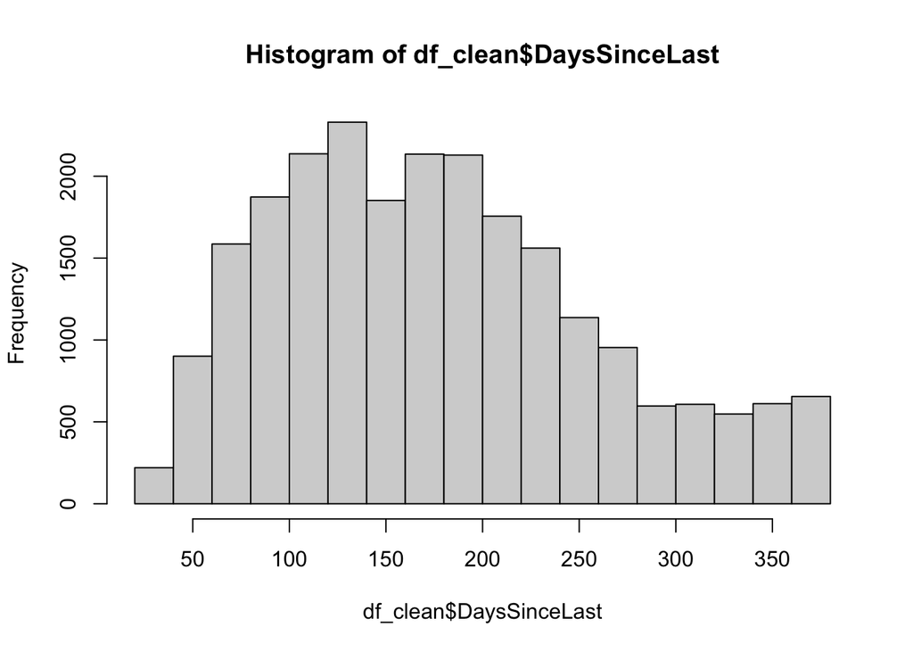

```r
# days since last meet (~recovery)
hist(df_clean$DaysSinceLast)
```

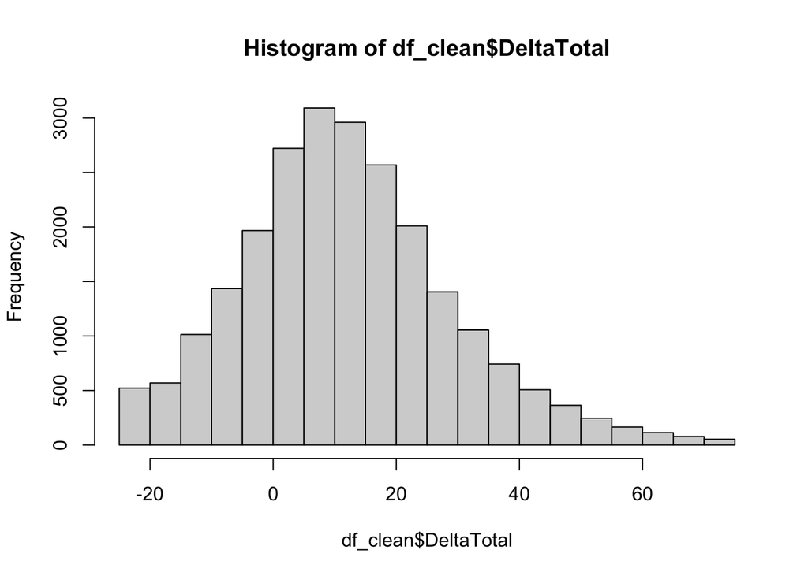

```r
# delta total
hist(df_clean$DeltaTotal)
```

```r
# age class distribution
table(df_clean$AgeClass)
```

```
24-34 35-39 40-44 45-49 50-54 55-59 60-64
16131  2398  1708  1220   991   681   460
```

```r
table(df_clean$Sex)
```

```
    F     M    Mx
10871 12718     0
```

```r
# time zone and direction Ns
table(df_clean$StateMeetTzDiff, df_clean$Direction)
```

```
     Eastward Local Westward
  -3        0     0      483
  -2        0     0      246
  -1        0     0      439
  0         0 21867        0
  1       261     0        0
  2       125     0        0
  3       168     0        0
```

```r
# setting local meet as reference level
df_clean <- df_clean |>
  mutate(
    StateMeetTzDiff = factor(StateMeetTzDiff),
    StateMeetTzDiff = relevel(StateMeetTzDiff, ref = "0")
  )
```

```r
# mixed model with random intercepts for each lifter
mod <- lmer(
  DeltaTotal ~ StateMeetTzDiff + MeetNumber + AgeClass + Sex + BodyweightKg + cDays + (1 | Name),
  data = df_clean
)
```

```
boundary (singular) fit: see help('isSingular')
```

```r
mod |>
  broom.mixed::tidy(effects = "fixed", conf.int = TRUE) |>
  rmarkdown::paged_table()
```

| effect | term | estimate | std.error | statistic | df | p.value | conf.low | conf.high |
| --- | --- | --- | --- | --- | --- | --- | --- | --- |
| fixed | (Intercept) | 13.46984331 | 0.505725325 | 26.634702 | 23572 | 5.117010e-154 | 12.47858899 | 14.4610976 |
| fixed | StateMeetTzDiff-3 | -2.92829960 | 0.761659735 | -3.844630 | 23572 | 1.210517e-04 | -4.42120191 | -1.4353973 |
| fixed | StateMeetTzDiff-2 | -3.85887677 | 1.061515785 | -3.635251 | 23572 | 2.783005e-04 | -5.93951631 | -1.7782372 |
| fixed | StateMeetTzDiff-1 | -3.97310937 | 0.798478478 | -4.975850 | 23572 | 6.541907e-07 | -5.53817880 | -2.4080400 |
| fixed | StateMeetTzDiff1 | -4.03240644 | 1.027903097 | -3.922944 | 23572 | 8.772135e-05 | -6.04716294 | -2.0176499 |
| fixed | StateMeetTzDiff2 | -3.51323527 | 1.482737996 | -2.369424 | 23572 | 1.782382e-02 | -6.41949758 | -0.6069730 |
| fixed | StateMeetTzDiff3 | -2.75534562 | 1.277932638 | -2.156096 | 23572 | 3.108624e-02 | -5.26017618 | -0.2505151 |
| fixed | MeetNumber | -2.24178102 | 0.072561534 | -30.894896 | 23572 | 1.740925e-205 | -2.38400632 | -2.0995557 |
| fixed | AgeClass35-39 | -1.44771329 | 0.364920944 | -3.967197 | 23572 | 7.293791e-05 | -2.16298193 | -0.7324447 |
| fixed | AgeClass40-44 | -1.68475736 | 0.423581192 | -3.977413 | 23572 | 6.987712e-05 | -2.51500387 | -0.8545108 |

[output cut: 7 more lines]

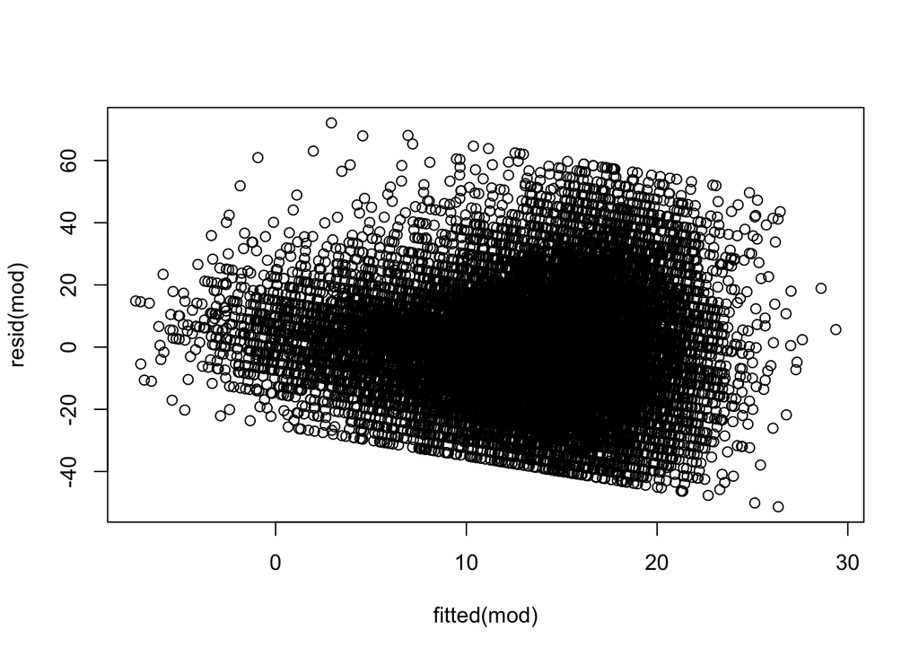

```r
plot(resid(mod) ~ fitted(mod))
```

```r
# model estimates
emm <- emmeans::emmeans(mod, ~ StateMeetTzDiff, pbkrtest.limit = Inf)
emm_df <- as.data.frame(emm)

emm_df <- emm_df %>%
  mutate(
    tz_signed = as.integer(as.character(StateMeetTzDiff)),
    Direction = case_when(
      tz_signed >  0 ~ "Eastward",
      tz_signed <  0 ~ "Westward",
      tz_signed == 0 ~ "Local"
    ),
    tz_abs = abs(tz_signed)
  )
```

```r
# duplicate local tz for plotting
emm_df_dup <- emm_df |>
  rbind(filter(emm_df, Direction == "Local")) |>
  arrange(as.numeric(tz_abs))

emm_df_dup$Direction[1] <- "Eastward"
emm_df_dup$Direction[2] <- "Westward"
```

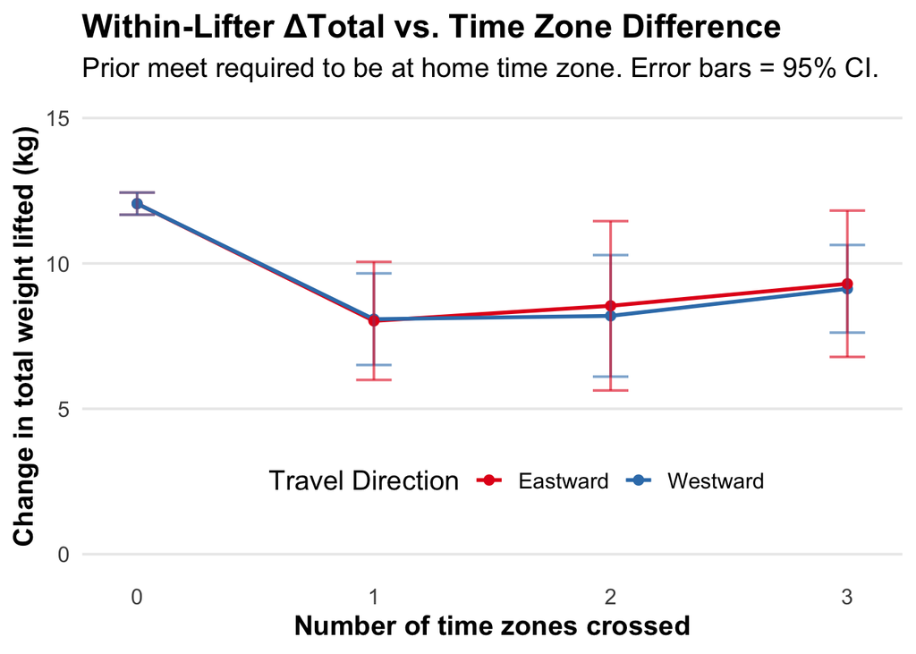

```r
(p <- emm_df_dup |>
    ggplot(aes(
      x = tz_abs,
      y = emmean,
      color = Direction
    )) +
    geom_line(linewidth = 1) +
    geom_point(size = 2) +
    geom_errorbar(
      aes(
        ymin = lower.CL,
        ymax = upper.CL
      ),
      width = 0.15,
      alpha = 0.6
    ) +
    scale_color_manual(values = c("Eastward" = "#e41a1c", "Westward" = "#377eb8")) +
    scale_x_continuous(breaks = 0:12) +
    labs(
      title = "Within-Lifter ΔTotal vs. Time Zone Difference",
      subtitle = "Prior meet required to be at home time zone. Error bars = 95% CI.",
      x = "Number of time zones crossed",
      y = "Change in total weight lifted (kg)",
      color = "Travel Direction"
    ) +
    scale_y_continuous(limits = c(0, 15), breaks = c(0, 5, 10, 15)) +
    theme_minimal(base_size = 15) +
    theme(
      axis.title.x = element_text(face = "bold"),
      axis.title.y = element_text(face = "bold"),
      plot.title = element_text(face = "bold"),
      panel.grid.minor = element_blank(),
      legend.position = c(0.53, .2),
      legend.direction = "horizontal",
      panel.grid.major.x = element_blank()
    )
)
```

```r
ggsave(
  filename = "../figs/delta_total_by_time_zone.jpg",
  plot = p,
  height = 1600,
  width = 2100,
  units = "px"
)
```